# Uvod u vizualizaciju podataka u R-u

## Geometrijski objekti (`geom_`)

Na primer, iste podatke možemo prikazati pomoću dva različita geometrijska objekta.

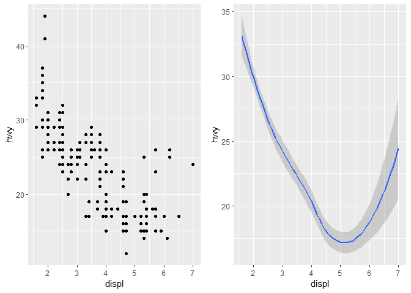

Svaki geometrijski objekat se dodaje na osnovni grafik u vidu lejera, pa ga često nazivamo i geometrijski lejer. U okviru geometrijskog lejera definiše se parametar `mapping` u okviru koga se definišu `aestetic` parametri. Međutim, nisu svi aestetic parametri zajednički za sve geometrije. Na primer, nije moguće definisati `aestetic` parametar `shape` za geometriju linije. Umesto toga, postoji `aestetic` parametar `linetype`.

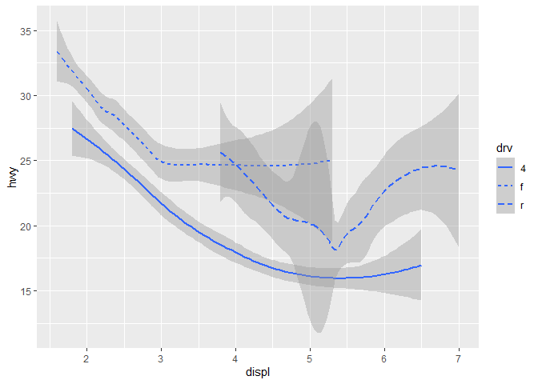

```r
ggplot(data = mpg) +
  geom_smooth(mapping = aes(x = displ, y = hwy, linetype = drv))
```

`ggplot` omogućava korišćenje preko 40 geometrijskih prikaza. Pregledni prikaz je dat u okviru [ggplot cheetsheet-a](https://raw.githubusercontent.com/rstudio/cheatsheets/master/data-visualization-2.1.pdf)

Neki geometrijski objekti (lejeri) služe za prikaz više podataka kroz jedan objekat. Kao na primer `geom_smooth`. Međutim, moguće je definisati `aestetic` parametar `group` koji će se odnositi na neku kategoričku promenljviu u podacima, čime će se definisati prikaz razlikičitih grupa podataka istom geometrijom.

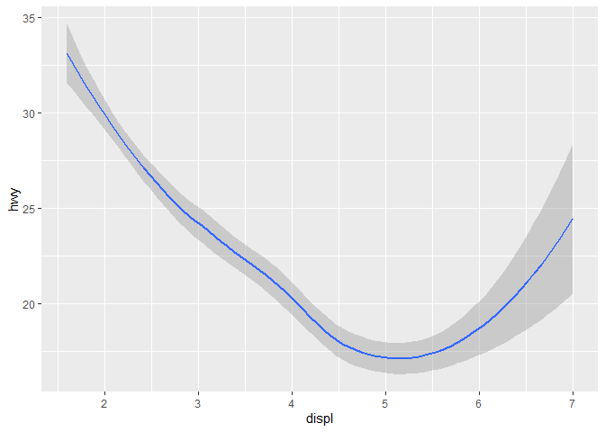

```r
ggplot(data = mpg) +
  geom_smooth(mapping = aes(x = displ, y = hwy))
```

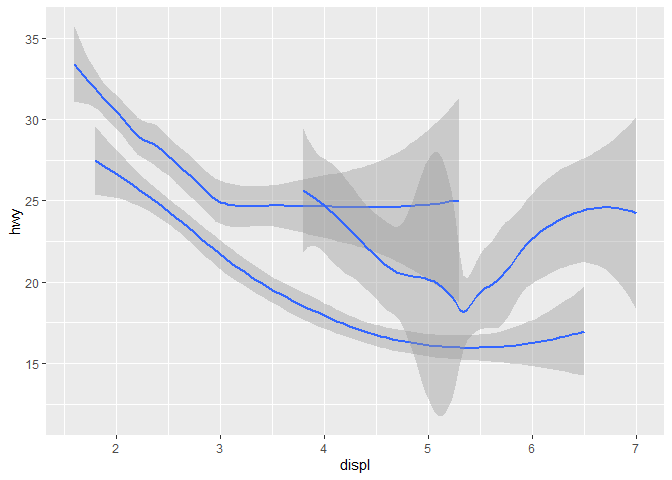

```r
ggplot(data = mpg) +
  geom_smooth(mapping = aes(x = displ, y = hwy, group = drv))
```

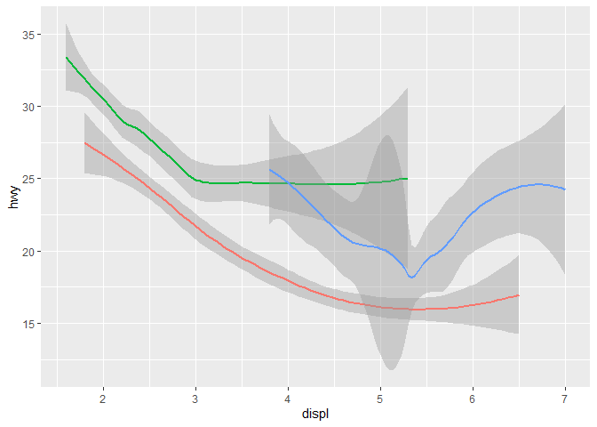

```r
ggplot(data = mpg) +
  geom_smooth(
    mapping = aes(x = displ, y = hwy, color = drv),
    show.legend = FALSE
  )
```

> Postoje brojne “ekstenzije” ggplot [ggplot extensions](https://exts.ggplot2.tidyverse.org/gallery/)